# Загрузка данных

```python
import pandas as pd
import numpy as np
import matplotlib.pyplot as plt
import seaborn as sns
from sklearn.model_selection import train_test_split, cross_val_score
from sklearn.preprocessing import StandardScaler, LabelEncoder
from sklearn.neighbors import KNeighborsRegressor
from sklearn.linear_model import LinearRegression
from sklearn.ensemble import RandomForestRegressor
from sklearn.metrics import mean_absolute_error, mean_squared_error, r2_score
from sklearn.impute import SimpleImputer
import warnings
warnings.filterwarnings('ignore')

file_path = r"E:\study4\ML\hotel_booking\hotel_bookings.csv"
```

# Информация о датасете

## Размер данных

```python
print(f"Размер данных: {df.shape}")
print(f"Количество строк: {df.shape[0]}")
print(f"Количество столбцов: {df.shape[1]}")
```

[output not shown]

## Первые пять строк датасета

```python
df.head()
```

[output not shown]

## Названия столбцов

```python
print(list(df.columns))
```

[output not shown]

## Описание столбцов по категориям

```python
column_descriptions = {
    'hotel': 'Тип отеля (City Hotel - городской отель, Resort Hotel - курортный отель)',
    'is_canceled': 'Флаг отмены бронирования (1 - отменено, 0 - не отменено)',
    'lead_time': 'Количество дней между датой бронирования и датой заезда',
    'arrival_date_year': 'Год заезда',
    'arrival_date_month': 'Месяц заезда',
    'arrival_date_week_number': 'Номер недели года заезда',
    'arrival_date_day_of_month': 'День месяца заезда',
    'stays_in_weekend_nights': 'Количество ночей в выходные дни (суббота, воскресенье)',
    'stays_in_week_nights': 'Количество ночей в будние дни (понедельник-пятница)',
    'adults': 'Количество взрослых гостей',
    'children': 'Количество детей',
    'babies': 'Количество младенцев',
    'meal': 'Тип питания: BB - Постель и завтрак, HB - Полупансион, FB - Полный пансион, SC - Без питания',
    'country': 'Страна происхождения гостя (код страны)',
    'market_segment': 'Сегмент рынка: Direct - прямое бронирование, Corporate - корпоративное, Online TA - онлайн тур-агент и т.д.',
    'distribution_channel': 'Канал распределения: TA - тур-агенты, TO - тур-операторы, Direct - прямой, Corporate - корпоративный',
    'is_repeated_guest': 'Флаг повторного гостя (1 - повторный, 0 - новый)',
    'previous_cancellations': 'Количество предыдущих отмен бронирований',
    'previous_bookings_not_canceled': 'Количество предыдущих бронирований, которые не были отменены',
    'reserved_room_type': 'Забронированный тип номера (код)',
    'assigned_room_type': 'Фактически предоставленный тип номера (код)',
    'booking_changes': 'Количество изменений/корректировок бронирования',
    'deposit_type': 'Тип депозита: No Deposit - без депозита, Non Refund - невозвращаемый, Refundable - возвращаемый',
    'agent': 'ID агента, через которого сделано бронирование',
    'company': 'ID компании',
    'days_in_waiting_list': 'Количество дней, которое бронирование находилось в листе ожидания',
    'customer_type': 'Тип клиента: Contract - по контракту, Group - группой, Transient - разовый, Transient-Party - разовый в группе',
    'adr': 'Average Daily Rate - средняя дневная цена номера',
    'required_car_parking_spaces': 'Количество запрошенных парковочных мест',
    'total_of_special_requests': 'Общее количество специальных запросов',
    'reservation_status': 'Статус бронирования: Check-Out - выехал, Canceled - отменено, No-Show - не явился',
    'reservation_status_date': 'Дата последнего обновления статуса бронирования'
}

column_categories = {
    'ИНФОРМАЦИЯ О БРОНИРОВАНИИ': [
        'hotel', 'is_canceled', 'lead_time', 'reservation_status',
        'reservation_status_date'
    ],
    'ДАТЫ ПРЕБЫВАНИЯ': [
        'arrival_date_year', 'arrival_date_month', 'arrival_date_week_number',
        'arrival_date_day_of_month', 'stays_in_weekend_nights',
        'stays_in_week_nights', 'days_in_waiting_list'
    ],
    'ИНФОРМАЦИЯ О ГОСТЯХ': [
        'adults', 'children', 'babies', 'country', 'is_repeated_guest',
        'customer_type'
    ],
    'ДЕТАЛИ БРОНИРОВАНИЯ': [
        'meal', 'market_segment', 'distribution_channel', 'deposit_type',
        'agent', 'company', 'booking_changes'
    ],
    'ИНФОРМАЦИЯ О НОМЕРЕ': [
        'reserved_room_type', 'assigned_room_type',
        'required_car_parking_spaces', 'total_of_special_requests'
    ],
    'ИСТОРИЯ И ФИНАНСЫ': [
        'previous_cancellations', 'previous_bookings_not_canceled', 'adr'
    ]
}

for category, columns in column_categories.items():
    print(f"\n{'='*150}")
    print(f"{category} ({len(columns)} столбцов):")
    print('='*150)

    for col in columns:
        if col in df.columns:
            desc = column_descriptions.get(col, "Описание отсутствует")
            print(f"{col:<35} | {desc:<90}")
            print('_'*150)
```

[output not shown]

## Выводы

На основе этих данных можно решать множество задач разных типов. Например:

### Задачи классификации

- Предсказание типа клиента, будет ли клиент повторным гостем | Определение лояльных клиентов для программ лояльности
- Классификация канала продаж, через какой канал придет клиент | Оптимизация маркетингово бюджета
- Предсказание типа питания

### Задачи регрессии

- Предсказание стоимости номера | Динамическое ценообразование
- Прогноз длительности пребывания | Планирование загрузки и уборки номеров
- За сколько дней бронируют | Планирование рекламных компаний

### Задачи кластеризации

- Сегментация клиентов
- Кластеризация периодов спроса

### Аналитичекие задачи

- Анализ сезонности и трендов
- Анализ эффективности каналов продаж
- Прогнозирование загрузки отеля
- Расчет ценности клиента
- Выявление "проблемных" бронирований
- Оптимизация управления доходами
- Прогнозирование специальных запросов, дополнительных услуг

А также многие другие

## Выбор задачи

Я выбрала задачу регрессии "Предсказание стоимости номера (ADR)".

Задача: Построение модели машинного обучения для прогнозирования средней дневной стоимости номера (Average Daily Rate - ADR) на основе характеристик бронирования и гостя.

Тип задачи: Многомерная регрессия

Целевая переменная: adr (Average Daily Rate) - непрерывная числовая переменная, представляющая среднюю дневную цену номера в евро.

Практическое применение: динамическое ценообраование, оптимизация доходов отеля, прогнозирование спроса и цен, разработка стратегий скидок и акций, анализ ценовой конкуренции

# 2-ое задание. Разбить данные на тестовую и обучающую выборку

В ходе анализа данных было замечено, что есть строки с отрицательным ADR, скорее всего это ошибка в датасете. Было принято решение просто удалить эти строки

```python
import pandas as pd
import numpy as np
from sklearn.model_selection import train_test_split

# 1. Чтение данных
file_path = r"E:\study4\ML\hotel_booking\hotel_bookings.csv"
df = pd.read_csv(file_path)

print("Данные успешно загружены!")
print(f"Исходный размер данных: {df.shape}")

# 2. Проверка и удаление строк с отрицательным ADR
print("\n=== ПРОВЕРКА И УДАЛЕНИЕ СТРОК С ОТРИЦАТЕЛЬНЫМ ADR ===")

# Анализ отрицательных значений перед удалением
negative_adr_mask = df['adr'] < 0
negative_adr_count = negative_adr_mask.sum()
negative_adr_percent = (negative_adr_count / len(df)) * 100

print(f"Найдено строк с отрицательным ADR: {negative_adr_count} ({negative_adr_percent:.4f}%)")
print(f"Минимальное значение ADR до очистки: {df['adr'].min():.2f} €")

if negative_adr_count > 0:
    # Показываем примеры строк с отрицательным ADR
    print("\nПримеры строк с отрицательным ADR:")
    negative_samples = df[negative_adr_mask][['hotel', 'adults', 'children', 'adr', 'reservation_status']].head()
    print(negative_samples.to_string())

    # Удаляем строки с отрицательным ADR
    df_clean = df[~negative_adr_mask].copy()
    print(f"\nУдалено строк: {negative_adr_count}")
else:
    df_clean = df.copy()
    print("Отрицательных значений ADR не найдено")

print(f"Размер данных после очистки: {df_clean.shape}")
print(f"Минимальное значение ADR после очистки: {df_clean['adr'].min():.2f} €")

def prepare_adr_data(df):
    # Исключаем целевой признак и проблемные столбцы
    exclude_cols = ['reservation_status', 'reservation_status_date', 'assigned_room_type']
    X = df.drop(['adr'] + exclude_cols, axis=1)
    y = df['adr']
    return X, y

# Используем очищенные данные
X, y = prepare_adr_data(df_clean)

# Разбиваем на train/test
X_train, X_test, y_train, y_test = train_test_split(
    X, y, test_size=0.3, random_state=42
)

print(f"\n=== РЕЗУЛЬТАТЫ РАЗДЕЛЕНИЯ ===")
print(f"Обучающая выборка: {X_train.shape}")
print(f"Тестовая выборка: {X_test.shape}")
print(f"Целевая переменная - ADR:")
print(f"  Min: {y.min():.2f} €, Max: {y.max():.2f} €, Mean: {y.mean():.2f} €, Std: {y.std():.2f} €")

# Дополнительная проверка распределения
print(f"\n=== ПРОВЕРКА РАСПРЕДЕЛЕНИЯ ===")
print(f"Обучающая выборка - ADR: Min={y_train.min():.2f} €, Mean={y_train.mean():.2f} €")
print(f"Тестовая выборка - ADR: Min={y_test.min():.2f} €, Mean={y_test.mean():.2f} €")

# Проверка, что отрицательных значений больше нет
assert (y < 0).sum() == 0, "Обнаружены отрицательные значения ADR после очистки!"
assert (y_train < 0).sum() == 0, "Обнаружены отрицательные значения ADR в обучающей выборке!"
assert (y_test < 0).sum() == 0, "Обнаружены отрицательные значения ADR в тестовой выборке!"

print("Проверка пройдена: отрицательных значений ADR нет ни в одной выборке")
```

```
Данные успешно загружены!
Исходный размер данных: (119390, 32)

=== ПРОВЕРКА И УДАЛЕНИЕ СТРОК С ОТРИЦАТЕЛЬНЫМ ADR ===
Найдено строк с отрицательным ADR: 1 (0.0008%)
Минимальное значение ADR до очистки: -6.38 €

Примеры строк с отрицательным ADR:
              hotel  adults  children   adr reservation_status
14969  Resort Hotel       2       0.0 -6.38          Check-Out

Удалено строк: 1
Размер данных после очистки: (119389, 32)
Минимальное значение ADR после очистки: 0.00 €

=== РЕЗУЛЬТАТЫ РАЗДЕЛЕНИЯ ===
Обучающая выборка: (83572, 28)
Тестовая выборка: (35817, 28)
Целевая переменная - ADR:
  Min: 0.00 €, Max: 5400.00 €, Mean: 101.83 €, Std: 50.54 €

=== ПРОВЕРКА РАСПРЕДЕЛЕНИЯ ===
Обучающая выборка - ADR: Min=0.00 €, Mean=101.89 €
Тестовая выборка - ADR: Min=0.00 €, Mean=101.71 €
Проверка пройдена: отрицательных значений ADR нет ни в одной выборке
```

# 3-е задание. Визуализировать данные, вычислить основные характеристики, интерпретировать результаты

```
=== ОСНОВНЫЕ ХАРАКТЕРИСТИКИ ДАННЫХ ===
Статистики ADR (целевая переменная):
Среднее: 101.83 €
Стандартное отклонение: 50.54 €
Минимум: 0.00 €
Максимум: 5400.00 €
Медиана: 94.59 €
```

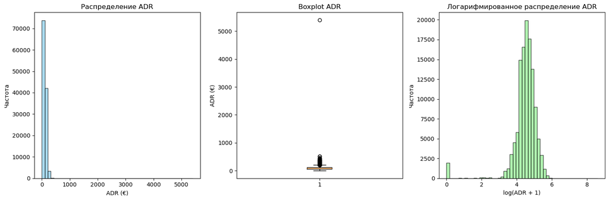

```python
# 3. Визуализировать данные и вычислить основные характеристики
print("=== ОСНОВНЫЕ ХАРАКТЕРИСТИКИ ДАННЫХ ===")

# Статистики целевой переменной
print("Статистики ADR (целевая переменная):")
print(f"Среднее: {y.mean():.2f} €")
print(f"Стандартное отклонение: {y.std():.2f} €")
print(f"Минимум: {y.min():.2f} €")
print(f"Максимум: {y.max():.2f} €")
print(f"Медиана: {y.median():.2f} €")

# Визуализация распределения ADR
plt.figure(figsize=(15, 5))

plt.subplot(1, 3, 1)
plt.hist(y, bins=50, alpha=0.7, color='skyblue', edgecolor='black')
plt.title('Распределение ADR')
plt.xlabel('ADR (€)')
plt.ylabel('Частота')

plt.subplot(1, 3, 2)
plt.boxplot(y)
plt.title('Boxplot ADR')
plt.ylabel('ADR (€)')

# Логарифмированное распределение для лучшей визуализации
plt.subplot(1, 3, 3)
plt.hist(np.log1p(y), bins=50, alpha=0.7, color='lightgreen', edgecolor='black')
plt.title('Логарифмированное распределение ADR')
plt.xlabel('log(ADR + 1)')
plt.ylabel('Частота')

plt.tight_layout()
plt.show()
```

[output not shown]

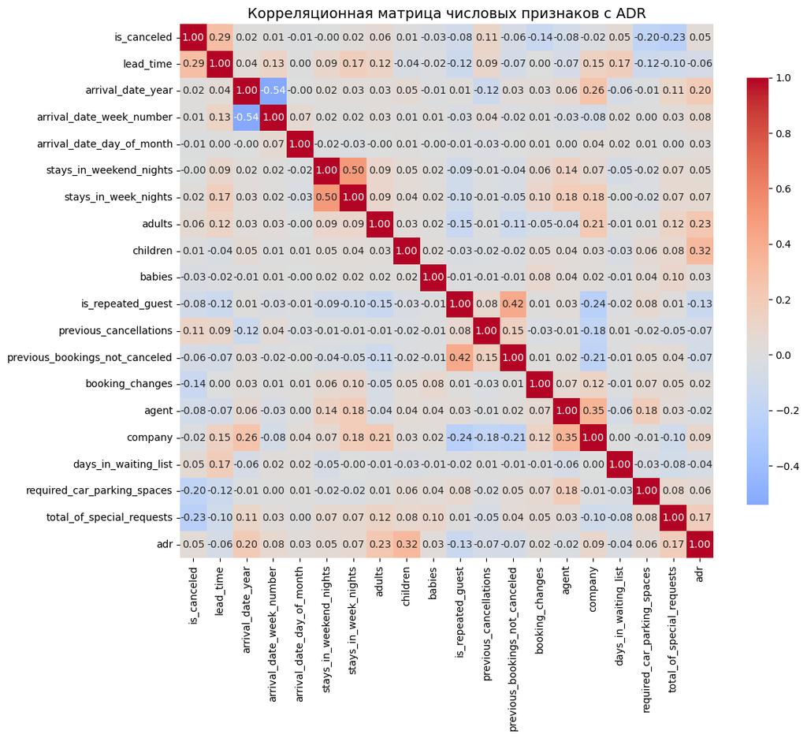

```
Топ-10 признаков по корреляции с ADR:
adr                            1.000000
children                       0.324855
adults                         0.230650
arrival_date_year              0.197606
total_of_special_requests      0.172176
company                        0.086376
arrival_date_week_number       0.075770
stays_in_week_nights           0.065273
required_car_parking_spaces    0.056625
stays_in_weekend_nights        0.049400
Name: adr, dtype: float64
```

```python
# Анализ числовых признаков
numeric_features = X.select_dtypes(include=[np.number]).columns
print("Числовые признаки:", list(numeric_features))

# Корреляционная матрица для числовых признаков
numeric_df = X[numeric_features].copy()
numeric_df['adr'] = y  # Добавляем целевую переменную

plt.figure(figsize=(12, 10))
correlation_matrix = numeric_df.corr()
sns.heatmap(correlation_matrix, annot=True, cmap='coolwarm', center=0,
            square=True, fmt='.2f', cbar_kws={"shrink": .8})
plt.title('Корреляционная матрица числовых признаков с ADR', fontsize=14)
plt.tight_layout()
plt.show()

# Анализ корреляции с ADR
print("Топ-10 признаков по корреляции с ADR:")
adr_corr = correlation_matrix['adr'].sort_values(ascending=False)
print(adr_corr.head(10))
```

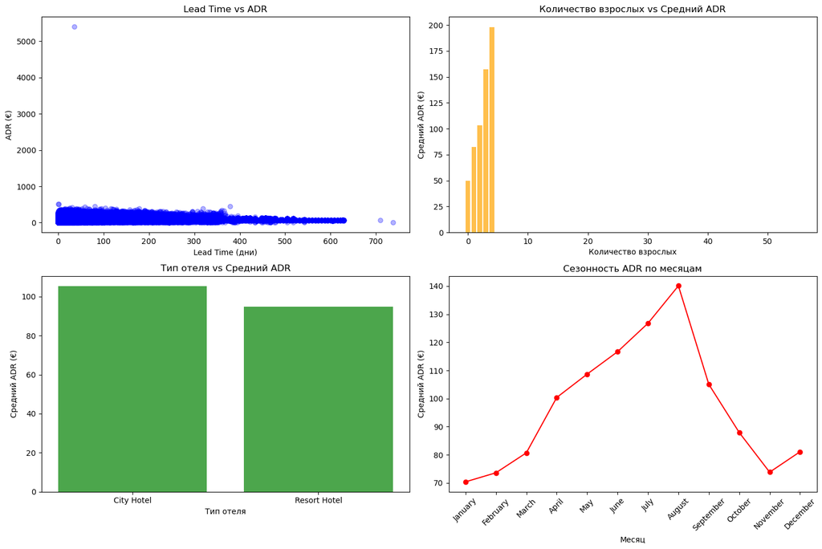

```python
# Визуализация важных признаков
fig, axes = plt.subplots(2, 2, figsize=(15, 10))

# Lead time vs ADR
axes[0, 0].scatter(X['lead_time'], y, alpha=0.3, color='blue')
axes[0, 0].set_xlabel('Lead Time (дни)')
axes[0, 0].set_ylabel('ADR (€)')
axes[0, 0].set_title('Lead Time vs ADR')

# Adults vs ADR
adults_adr = df.groupby('adults')['adr'].mean()
axes[0, 1].bar(adults_adr.index, adults_adr.values, color='orange', alpha=0.7)
axes[0, 1].set_xlabel('Количество взрослых')
axes[0, 1].set_ylabel('Средний ADR (€)')
axes[0, 1].set_title('Количество взрослых vs Средний ADR')

# Hotel type vs ADR
hotel_adr = df.groupby('hotel')['adr'].mean()
axes[1, 0].bar(hotel_adr.index, hotel_adr.values, color='green', alpha=0.7)
axes[1, 0].set_xlabel('Тип отеля')
axes[1, 0].set_ylabel('Средний ADR (€)')
axes[1, 0].set_title('Тип отеля vs Средний ADR')

# Month vs ADR
month_order = ['January', 'February', 'March', 'April', 'May', 'June',
               'July', 'August', 'September', 'October', 'November', 'December']
df['arrival_date_month'] = pd.Categorical(df['arrival_date_month'], categories=month_order, ordered=True)
month_adr = df.groupby('arrival_date_month')['adr'].mean()
axes[1, 1].plot(month_adr.index, month_adr.values, marker='o', color='red')
axes[1, 1].set_xlabel('Месяц')
axes[1, 1].set_ylabel('Средний ADR (€)')
axes[1, 1].set_title('Сезонность ADR по месяцам')
plt.xticks(rotation=45)

plt.tight_layout()
plt.show()
```

# 4-ое задание. Обработать пропущенные значения (или убедиться, что их нет)

```python
# 4. Обработать пропущенные значения
print("=== ОБРАБОТКА ПРОПУЩЕННЫХ ЗНАЧЕНИЙ ===")

missing_data = X.isnull().sum()
missing_percent = (X.isnull().sum() / len(X)) * 100

missing_info = pd.DataFrame({
    'Количество пропусков': missing_data,
    'Процент пропусков': missing_percent
}).sort_values('Количество пропусков', ascending=False)

print("Пропущенные значения в признаках:")
display(missing_info[missing_info['Количество пропусков'] > 0])

# Стратегия заполнения пропусков
X_clean = X.copy()
fill_strategy = {
    'children': 0,
    'country': 'Unknown',
    'agent': 0,
    'company': 0
}

for column, value in fill_strategy.items():
    if column in X_clean.columns:
        before = X_clean[column].isnull().sum()
        X_clean[column] = X_clean[column].fillna(value)
        after = X_clean[column].isnull().sum()
        print(f"Заполнено {before} пропусков в столбце '{column}'")

print(f"\nПосле обработки пропусков: {X_clean.isnull().sum().sum()} пропущенных значений")

# Обновляем train/test после очистки
X_train_clean = X_clean.loc[X_train.index]
X_test_clean = X_clean.loc[X_test.index]
```

```
=== ОБРАБОТКА ПРОПУЩЕННЫХ ЗНАЧЕНИЙ ===
Пропущенные значения в признаках:
```

|  | Количество пропусков | Процент пропусков |
| --- | --- | --- |
| company | 112592 | 94.306846 |
| agent | 16340 | 13.686353 |
| country | 488 | 0.408748 |
| children | 4 | 0.003350 |

```
Заполнено 4 пропусков в столбце 'children'
Заполнено 488 пропусков в столбце 'country'
Заполнено 16340 пропусков в столбце 'agent'
Заполнено 112592 пропусков в столбце 'company'

После обработки пропусков: 0 пропущенных значений
```

# 5-ое задание. Обработать категориальные признаки

```python
# 5. Обработать категориальные признаки
print("=== ОБРАБОТКА КАТЕГОРИАЛЬНЫХ ПРИЗНАКОВ ===")

categorical_columns = X_clean.select_dtypes(include=['object']).columns
print("Категориальные признаки:", list(categorical_columns))

X_encoded = X_clean.copy()

# Анализ уникальных значений
print("\nКоличество уникальных значений в категориальных признаках:")
for column in categorical_columns:
    unique_count = X_encoded[column].nunique()
    print(f"{column}: {unique_count} уникальных значений")

# Кодирование категориальных признаков
for column in categorical_columns:
    if X_encoded[column].nunique() <= 10:
        # One-Hot Encoding для малого количества категорий
        dummies = pd.get_dummies(X_encoded[column], prefix=column)
        X_encoded = pd.concat([X_encoded, dummies], axis=1)
        X_encoded.drop(column, axis=1, inplace=True)
        print(f"Закодирован {column} с помощью One-Hot Encoding")
    else:
        # Label Encoding для многих категорий
        le = LabelEncoder()
        X_encoded[column] = le.fit_transform(X_encoded[column].astype(str))
        print(f"Закодирован {column} с помощью Label Encoding")

print(f"\nРазмер данных после кодирования: {X_encoded.shape}")

# Обновляем train/test после кодирования
X_train_encoded = X_encoded.loc[X_train.index]
X_test_encoded = X_encoded.loc[X_test.index]
```

```
=== ОБРАБОТКА КАТЕГОРИАЛЬНЫХ ПРИЗНАКОВ ===
Категориальные признаки: ['hotel', 'arrival_date_month', 'meal', 'country', 'market_segment', 'distribution_channel', 'reserved_room_type', 'deposit_type', 'customer_type']

Количество уникальных значений в категориальных признаках:
hotel: 2 уникальных значений
arrival_date_month: 12 уникальных значений
meal: 5 уникальных значений
country: 178 уникальных значений
market_segment: 8 уникальных значений
distribution_channel: 5 уникальных значений
reserved_room_type: 10 уникальных значений
deposit_type: 3 уникальных значений
customer_type: 4 уникальных значений
Закодирован hotel с помощью One-Hot Encoding
Закодирован arrival_date_month с помощью Label Encoding
Закодирован meal с помощью One-Hot Encoding
Закодирован country с помощью Label Encoding
Закодирован market_segment с помощью One-Hot Encoding
Закодирован distribution_channel с помощью One-Hot Encoding
Закодирован reserved_room_type с помощью One-Hot Encoding
Закодирован deposit_type с помощью One-Hot Encoding
Закодирован customer_type с помощью One-Hot Encoding

Размер данных после кодирования: (119389, 58)
```

# 6-ое задание. Провести нормализацию (или объяснить, почему в вашем случае она не нужна)

```python
# 6. Провести нормализацию
print("=== НОРМАЛИЗАЦИЯ ДАННЫХ ===")

"""
НОРМАЛИЗАЦИЯ НУЖНА потому что:
1. KNN и линейные модели чувствительны к масштабу признаков
2. Признаки имеют разные единицы измерения и диапазоны
3. Нормализация улучшает сходимость и производительность моделей
"""

scaler = StandardScaler()
X_train_scaled = scaler.fit_transform(X_train_encoded)
X_test_scaled = scaler.transform(X_test_encoded)

print("Данные нормализованы с помощью StandardScaler")
print(f"Размер обучающей выборки: {X_train_scaled.shape}")
print(f"Размер тестовой выборки: {X_test_scaled.shape}")
```

```
=== НОРМАЛИЗАЦИЯ ДАННЫХ ===
Данные нормализованы с помощью StandardScaler
Размер обучающей выборки: (83572, 58)
Размер тестовой выборки: (35817, 58)
```

# 7-ое задание. Запустить классификатор (ререссию) ближайших соседей или другой метод (аргументируйте выбор!)

```python
# 7. Запуск регрессии ближайших соседей
print("=== РЕГРЕССИЯ БЛИЖАЙШИХ СОСЕДЕЙ ===")

"""
ВЫБОР KNN РЕГРЕССОРА АРГУМЕНТИРОВАН:
- Простота реализации и интерпретации
- Хорошая производительность на небольших-средних датасетах
- Не делает предположений о распределении данных
- Хорошо работает, когда есть локальные зависимости в данных
- Позволяет легко подобрать оптимальную сложность модели через параметр k
"""

knn = KNeighborsRegressor(n_neighbors=5)
knn.fit(X_train_scaled, y_train)

# Предсказания
y_pred_train_knn = knn.predict(X_train_scaled)
y_pred_test_knn = knn.predict(X_test_scaled)

print("KNN регрессор обучен (k=5)")
```

```
=== РЕГРЕССИЯ БЛИЖАЙШИХ СОСЕДЕЙ ===
KNN регрессор обучен (k=5)
```

# 8-ое задание. Вычислить ошибки на обучающей и тестовой выборках. Напечатайте матрицы рассогласования (для задачи классификации). Прокомментируйте. Выбрать оптимальное значение гиперпараметра (к-ва ближайших соседей)

```python
# 8. Вычисление ошибок и подбор гиперпараметра
print("=== ОЦЕНКА МОДЕЛИ И ПОДБОР ГИПЕРПАРАМЕТРА ===")

def evaluate_regression(y_true, y_pred, dataset_name):
    """Функция для оценки регрессионной модели"""
    mae = mean_absolute_error(y_true, y_pred)
    mse = mean_squared_error(y_true, y_pred)
    rmse = np.sqrt(mse)
    r2 = r2_score(y_true, y_pred)

    print(f"{dataset_name}:")
    print(f"  MAE: {mae:.2f} €")
    print(f"  RMSE: {rmse:.2f} €")
    print(f"  R²: {r2:.4f}")
    print(f"  Средняя ошибка: {mae:.2f} € ({mae/y_true.mean()*100:.1f}% от средней цены)")

    return mae, rmse, r2

print("KNN (k=5) результаты:")
train_mae, train_rmse, train_r2 = evaluate_regression(y_train, y_pred_train_knn, "Обучающая выборка")
test_mae, test_rmse, test_r2 = evaluate_regression(y_test, y_pred_test_knn, "Тестовая выборка")
```

```
=== ОЦЕНКА МОДЕЛИ И ПОДБОР ГИПЕРПАРАМЕТРА ===
KNN (k=5) результаты:
Обучающая выборка:
  MAE: 12.26 €
  RMSE: 25.87 €
  R²: 0.7480
  Средняя ошибка: 12.26 € (12.0% от средней цены)
Тестовая выборка:
  MAE: 15.32 €
  RMSE: 26.44 €
  R²: 0.6978
  Средняя ошибка: 15.32 € (15.1% от средней цены)
```

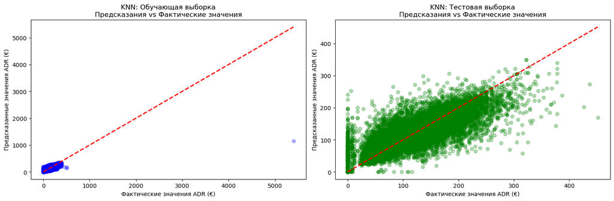

```python
# Визуализация предсказаний vs фактические значения
plt.figure(figsize=(15, 5))

plt.subplot(1, 2, 1)
plt.scatter(y_train, y_pred_train_knn, alpha=0.3, color='blue')
plt.plot([y_train.min(), y_train.max()], [y_train.min(), y_train.max()], 'r--', lw=2)
plt.xlabel('Фактические значения ADR (€)')
plt.ylabel('Предсказанные значения ADR (€)')
plt.title('KNN: Обучающая выборка\nПредсказания vs Фактические значения')

plt.subplot(1, 2, 2)
plt.scatter(y_test, y_pred_test_knn, alpha=0.3, color='green')
plt.plot([y_test.min(), y_test.max()], [y_test.min(), y_test.max()], 'r--', lw=2)
plt.xlabel('Фактические значения ADR (€)')
plt.ylabel('Предсказанные значения ADR (€)')
plt.title('KNN: Тестовая выборка\nПредсказания vs Фактические значения')

plt.tight_layout()
plt.show()
```

```
=== ПОДБОР ОПТИМАЛЬНОГО КОЛИЧЕСТВА СОСЕДЕЙ ===
```

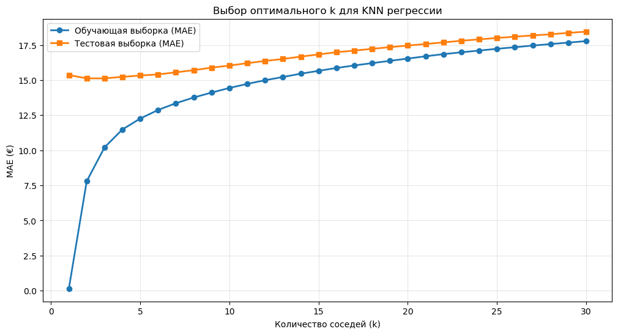

```
Лучшее значение k: 3
Лучшая MAE на тестовой выборке: 15.12 €

KNN с k=3 (финальная модель):
Тестовая выборка:
  MAE: 15.12 €
  RMSE: 26.86 €
  R²: 0.6882
  Средняя ошибка: 15.12 € (14.9% от средней цены)
```

```
(15.120116332095563, 26.860390519160894, 0.6882198460892435)
```

```python
# Подбор оптимального k для KNN
print("=== ПОДБОР ОПТИМАЛЬНОГО КОЛИЧЕСТВА СОСЕДЕЙ ===")

train_errors = []
test_errors = []
k_values = range(1, 31)

for k in k_values:
    knn_temp = KNeighborsRegressor(n_neighbors=k)
    knn_temp.fit(X_train_scaled, y_train)

    y_pred_train = knn_temp.predict(X_train_scaled)
    y_pred_test = knn_temp.predict(X_test_scaled)

    train_errors.append(mean_absolute_error(y_train, y_pred_train))
    test_errors.append(mean_absolute_error(y_test, y_pred_test))

# Визуализация
plt.figure(figsize=(12, 6))
plt.plot(k_values, train_errors, label='Обучающая выборка (MAE)', marker='o', linewidth=2)
plt.plot(k_values, test_errors, label='Тестовая выборка (MAE)', marker='s', linewidth=2)
plt.xlabel('Количество соседей (k)')
plt.ylabel('MAE (€)')
plt.title('Выбор оптимального k для KNN регрессии')
plt.legend()
plt.grid(True, alpha=0.3)
plt.show()

# Лучший k
best_k = k_values[np.argmin(test_errors)]
best_mae = min(test_errors)

print(f"Лучшее значение k: {best_k}")
print(f"Лучшая MAE на тестовой выборке: {best_mae:.2f} €")

# Обучение модели с лучшим k
knn_best = KNeighborsRegressor(n_neighbors=best_k)
knn_best.fit(X_train_scaled, y_train)
y_pred_best_knn = knn_best.predict(X_test_scaled)

print(f"\nKNN с k={best_k} (финальная модель):")
evaluate_regression(y_test, y_pred_best_knn, "Тестовая выборка")
```

```python
# 9. Запуск других регрессоров и сравнение результатов
print("=== СРАВНЕНИЕ РАЗЛИЧНЫХ РЕГРЕССОРОВ ===")

models = {
    'Linear Regression': LinearRegression(),
    'Random Forest': RandomForestRegressor(n_estimators=100, random_state=42, max_depth=10),
    f'KNN (k={best_k})': KNeighborsRegressor(n_neighbors=best_k)
}

results = {}

print("Обучение моделей...")
for name, model in models.items():
    print(f"\n--- {name} ---")

    if name == 'KNN (k={best_k})':
        # KNN использует нормализованные данные
        model.fit(X_train_scaled, y_train)
        y_pred_test = model.predict(X_test_scaled)
    else:
        # Другие модели используют ненормализованные данные после кодирования
        model.fit(X_train_encoded, y_train)
        y_pred_test = model.predict(X_test_encoded)

    mae = mean_absolute_error(y_test, y_pred_test)
    rmse = np.sqrt(mean_squared_error(y_test, y_pred_test))
    r2 = r2_score(y_test, y_pred_test)

    results[name] = {
        'MAE': mae,
        'RMSE': rmse,
        'R²': r2,
        'predictions': y_pred_test,
        'model': model
    }

    print(f"MAE: {mae:.2f} €")
    print(f"RMSE: {rmse:.2f} €")
    print(f"R²: {r2:.4f}")

# Сравнение моделей
print("\n" + "="*60)
print("СРАВНЕНИЕ МОДЕЛЕЙ (отсортировано по MAE):")
print("="*60)

results_df = pd.DataFrame({
    name: [result['MAE'], result['RMSE'], result['R²']]
    for name, result in results.items()
}, index=['MAE', 'RMSE', 'R²']).T

results_df = results_df.sort_values('MAE')
display(results_df.round(4))
```

```
=== СРАВНЕНИЕ РАЗЛИЧНЫХ РЕГРЕССОРОВ ===
Обучение моделей...

--- Linear Regression ---
MAE: 25.05 €
RMSE: 34.99 €
R²: 0.4708

--- Random Forest ---
MAE: 15.30 €
RMSE: 23.51 €
R²: 0.7612

--- KNN (k=3) ---
MAE: 19.63 €
RMSE: 33.91 €
R²: 0.5031

============================================================
СРАВНЕНИЕ МОДЕЛЕЙ (отсортировано по MAE):
============================================================
```

|  | MAE | RMSE | R² |
| --- | --- | --- | --- |
| Random Forest | 15.3009 | 23.5078 | 0.7612 |
| KNN (k=3) | 19.6261 | 33.9090 | 0.5031 |
| Linear Regression | 25.0546 | 34.9935 | 0.4708 |